# Compare Word Frequencies in Executive Summaries and Text Bodies

Malte Lüken

2022-07-18

In this document, we compare word frequencies between executive summaries and the main text of reports from the OECD corpus “Studies on Water”. The corpus consists of 55 reports of which all but one include an executive summary. For the main text, we included all chapters of each report, but excluded forewords, prefaces, appendices, and background material sections.

```
##       feature feat_freq   feat_prop
## 1       manag     13319 0.008504346
## 2      govern     11965 0.007304393
## 3         use     11811 0.007998576
## 4      polici     10740 0.006622162
## 5     resourc      8507 0.005513442
## 6       level      7990 0.004964252
## 7     develop      7828 0.005454008
## 8      servic      7767 0.005968037
## 9        cost      7591 0.005659561
## 10       risk      7330 0.004627465
## 11 agricultur      7074 0.004656852
## 12    countri      6750 0.004991498
## 13     sector      6291 0.004660409
## 14       plan      6177 0.003617399
## 15     provid      6149 0.004311758
## 16     system      6038 0.004182379
## 17     nation      5976 0.003652575
## 18    increas      5901 0.004101103
## 19      basin      5832 0.003230925
## 20     public      5821 0.003863396
```

The next table shows the top 20 most frequent words in the executive summaries:

```
##       feature feat_freq   feat_prop
## 1      polici       716 0.013675191
## 2       manag       504 0.011445637
## 3     countri       483 0.008605664
## 4      financ       452 0.006577512
## 5      govern       437 0.008858851
## 6         use       388 0.008859155
## 7      servic       367 0.006913782
## 8      sector       346 0.006962860
## 9        cost       340 0.006443051
## 10    develop       338 0.006660346
## 11    resourc       328 0.007225184
## 12      level       327 0.005803462
## 13       need       318 0.006102556
## 14     invest       306 0.005722295
## 15       risk       301 0.007362370
## 16 agricultur       294 0.005869931
## 17      sanit       281 0.005227866
## 18    increas       257 0.004961874
## 19     improv       253 0.005412701
## 20     econom       237 0.005502602
```

To compare word proportions between both parts, we choose a visual approach and plot them against each other in a scatter plot. We focus on word proportions because the executive summaries contain much less total words than the main text, that is, we interpret frequencies relatively to the size of the text. The plot shows the proportions of different words in the main text (x-axis) vs. the executive summaries (y-axis). For example, it can be seen that the word stem *polici* is relatively frequent in both but much more in the executive summaries. In general, words that are above the dashed line are relatively more frequent in the executive summaries and words in the upper right corner are more frequent in both parts.

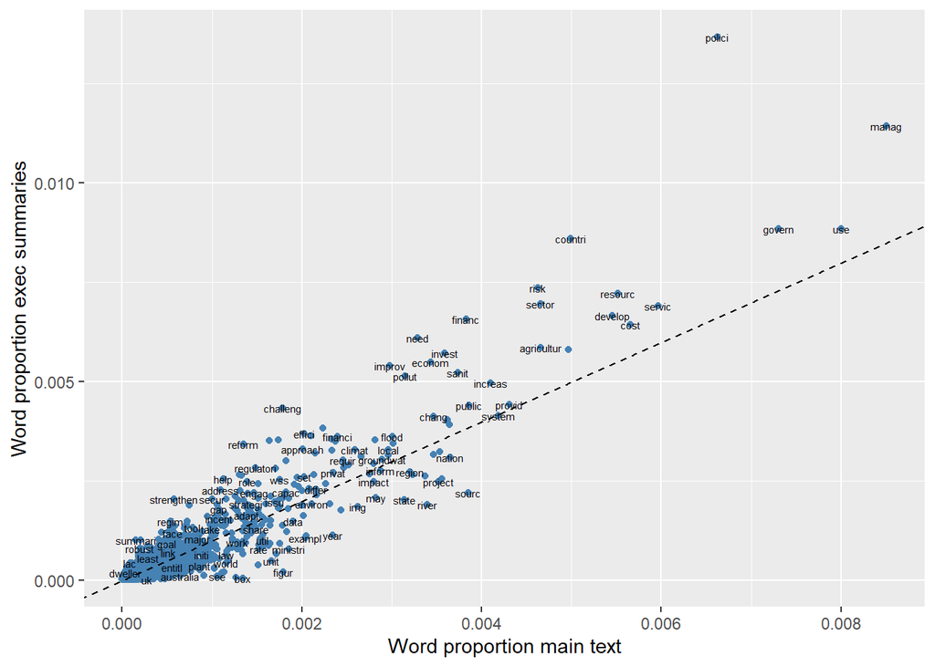

**Commentary on Differences in Word Frequencies (Malte)**

The results show substantial differences in relative word frequencies (i.e., proportions) between executive summaries and the main text. In the two tables, we can see that financial/economic terms are more prominent in the executive summaries. For example, the word stem “financ” is not included in the top 20 of the main text, whereas it is at rank four in the summaries. Similarly, the top 20 of the summaries include terms such as “invest” and “econom” which are not part of the main text top 20. This difference is supported by the figure, showing that terms such as “financ” and “invest” are relatively more frequent in the summaries.